# Wie steil sind Wiens Radstrecken?

Um diese Frage zu beantworten brauchen wir 1) die Radstrecken und 2) ein Geländeprofil.

Die Magistratsabteilung für Stadtvermessung (MA 41) bietet ein Geländemodell von Wien als Schichtenlinien in 1m Auflösung: https://www.data.gv.at/katalog/dataset/e45374c0-3e40-434c-92dc-203492ccee49 Laut MA 41 auch mit respektabler Genauigkeit:

> In den Gebieten, in welchen das digitale Geländemodell zum überwiegenden Teil auf den Daten der Mehrzweckkarte basiert, beträgt die Höhengenauigkeit im Straßenraum plus/minus 10 Zentimeter und im Blockinnenbereich plus/minus 25 Zentimeter. In bewaldeten Bereichen, wo das digitale Geländemodell aus Laserscandaten abgeleitet wurde, beträgt die Höhengenauigkeit im flachen Gelände plus/minus 20 Zentimeter und im steilen Gelände plus/minus 1 Meter.

Uns interessieren alle Strecken die von Radfahrenden verwendet werden. Von der Stadt Wien gibt es dazu kein Datenset, lediglich die dedizierte Radinfrastruktur oder den Straßengraphen. Deswegen greifen wir auf die Daten der OpenStreetMap zurück, mit entsprechender Filterung:

- grundsätzlich beradelbare Strecken ohne jene die explizit als nicht beradelbar markiert sind (`bicycle~no|use_sidepath`)
- tendenziell nicht beradelbare Strecken die explizit als beradelbar markiert sind (`bicycle~yes|designated|permissive`)

```python
import pandas as pd
import osmnx as ox
import networkx as nx
import geopandas as gpd
from shapely import wkt, box
from shapely.ops import substring
import matplotlib.pyplot as plt
import matplotlib.colors as mcolors
from tqdm import tqdm


street_graph = ox.graph_from_place("Vienna, Austria", custom_filter='["highway"~"living_street|residential|tertiary|tertiary_link|secondary|secondary_link|primary|primary_link|unclassified|cycleway"]["bicycle"!~"no|use_sidepath"]', retain_all=True)
other_graph = ox.graph_from_place("Vienna, Austria", custom_filter='["highway"~"service|pedestrian|track|footway|bridleway|path|construction"]["bicycle"~"yes|designated|permissive"]', retain_all=True)
merged_graph = nx.compose(street_graph, other_graph)
bikeable_lines = ox.graph_to_gdfs(merged_graph, nodes=False)
bikeable_lines = bikeable_lines.to_crs(epsg=31256)

contour_lines = pd.read_csv('datasets/hoehenlinien.csv')
contour_lines['geometry'] = contour_lines['SHAPE'].apply(wkt.loads)
contour_lines = gpd.GeoDataFrame(contour_lines, geometry='geometry', crs="EPSG:4326")
contour_lines = contour_lines.to_crs(epsg=31256)
```

```python
edges = bikeable_lines.copy()
edges.index = edges.index.droplevel('key') if 'key' in edges.index.names else edges.index

edge_set = set(edges.index)
mask = [(v, u) not in edge_set or u < v for u, v in edges.index]

bikeable_lines = bikeable_lines[mask]
```

Gibt es eh nur einfache Linien?

```python
print(contour_lines.geom_type.unique())
```

```
['LineString']
```

```python
print(bikeable_lines.geom_type.unique())
```

```
['LineString']
```

Schauen wir uns die Datensets mal an. Für ein bissi Steigung im Bereich der Berggasse.

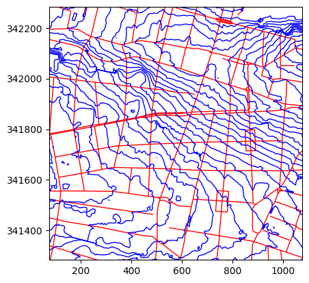

```python
berggasse_x, berggasse_y = 576, 341784
bbox_berggasse = box(berggasse_x - 500, berggasse_y - 500, berggasse_x + 500, berggasse_y + 500)
_, ax = plt.subplots()
bikeable_lines[bikeable_lines.intersects(bbox_berggasse)].plot(ax=ax, color="red", linewidth=1)
contour_lines[contour_lines.intersects(bbox_berggasse)].plot(ax=ax, color="blue", linewidth=1)
minx, miny, maxx, maxy = bbox_berggasse.bounds
ax.set_xlim(minx, maxx)
ax.set_ylim(miny, maxy)
plt.show()
```

Wie berechnen wir jetzt die Neigung der Radstrecken? Folgender Ansatz:

1. Alle Punkte finden an denen sich Radstrecken und Höhenlinien überschneiden
2. Radstrecken an diesen Punkten aufteilen
3. Für jedes Segment die Steigung berechnen

Als erstes also die Überschneidungspunkte von Radstrecken und Höhenlinien finden:

```python
contour_sindex = contour_lines.sindex
intersections = []

for bikeable_idx, bikeable_line in tqdm(bikeable_lines.geometry.items(), total=len(bikeable_lines)):
    possibly_intersecting_contour_lines_index = list(contour_sindex.intersection(bikeable_line.bounds))
    possibly_intersecting_contour_lines = contour_lines.iloc[possibly_intersecting_contour_lines_index]

    for contour_line_idx, contour_line in possibly_intersecting_contour_lines.geometry.items():
        if bikeable_line.intersects(contour_line):
            intersection = bikeable_line.intersection(contour_line)
            if intersection.geom_type == 'Point':
                intersections.append({
                    'bikable_line_id': bikeable_idx,
                    'geometry': intersection,
                    'elevation': contour_lines.loc[contour_line_idx, 'HOEHE_ADRIA']
                })
            elif intersection.geom_type == 'MultiPoint':
                for point in intersection.geoms:
                    intersections.append({
                        'bikable_line_id': bikeable_idx,
                        'geometry': point,
                        'elevation': contour_lines.loc[contour_line_idx, 'HOEHE_ADRIA']
                    })

intersections = gpd.GeoDataFrame(intersections, geometry='geometry', crs=bikeable_lines.crs)
```

Als nächstes die Radstrecken an den Höhenlinien-Schnittpunkten in Segmente aufteilen und deren Steigung berechnen.  
Hier wird es schwieriger:

```python
from shapely.geometry import Point, LineString

def estimate_elevation(point, search_radius):
    point = Point(point)
    bbox = point.buffer(search_radius).bounds
    candidate_contours = contour_lines.cx[bbox[0]:bbox[2], bbox[1]:bbox[3]].copy()
    if len(candidate_contours) < 2:
        return None

    candidate_contours['distance'] = candidate_contours.geometry.distance(point)
    candidate_contours = candidate_contours.sort_values('distance')
    first_contour_line = candidate_contours.iloc[0]

    for idx in range(1, len(candidate_contours)):
        second_contour_line = candidate_contours.iloc[idx]
        closest_point_on_second_contour_line = second_contour_line.geometry.interpolate(second_contour_line.geometry.project(point))
        shortest_line_to_second_contour_line = LineString([point, closest_point_on_second_contour_line])

        if not shortest_line_to_second_contour_line.crosses(first_contour_line.geometry) and not shortest_line_to_second_contour_line.within(first_contour_line.geometry):
            total_distance = first_contour_line.distance + second_contour_line.distance
            if total_distance == 0:
                return (first_contour_line['HOEHE_ADRIA'] + second_contour_line['HOEHE_ADRIA']) / 2
            elevation = first_contour_line['HOEHE_ADRIA'] + (first_contour_line.distance / total_distance) * (second_contour_line['HOEHE_ADRIA'] - first_contour_line['HOEHE_ADRIA'])
            return elevation

    return None


segments = []

for bikeable_idx, bikeable_line in tqdm(bikeable_lines.geometry.items(), total=len(bikeable_lines)):
    if bikeable_lines.loc[bikeable_idx]['bridge'] == 'yes' or bikeable_lines.loc[bikeable_idx]['tunnel'] == 'yes':
        segments.append({
            'geometry': bikeable_line,
            'elevation_delta': None,
            'length': bikeable_line.length,
            'slope': None
        })
        continue

    current_intersections = intersections[intersections['bikable_line_id'] == bikeable_idx]

    if len(current_intersections) == 0:
        from_elevation = estimate_elevation(bikeable_line.coords[0], search_radius=500)
        to_elevation = estimate_elevation(bikeable_line.coords[-1], search_radius=500)
        elevation_delta = 0 if from_elevation is None or to_elevation is None else abs(from_elevation - to_elevation)
        segments.append({
            'geometry': bikeable_line,
            'elevation_delta': elevation_delta,
            'length': bikeable_line.length,
            'slope': elevation_delta / bikeable_line.length if bikeable_line.length > 0 else 0
        })
        continue

    current_intersections = current_intersections.copy()
    current_intersections['distance'] = current_intersections.geometry.apply(lambda p: bikeable_line.project(p))
    current_intersections = current_intersections.sort_values('distance').drop_duplicates(subset=['distance'], keep='first')
    current_intersections = current_intersections.reset_index(drop=True)

    if current_intersections.loc[0, 'distance'] > 0:
        from_distance = 0
        to_distance = current_intersections.loc[0, 'distance']
        segment = substring(bikeable_line, from_distance, to_distance)
        from_elevation = estimate_elevation(segment.coords[0], search_radius=500)
        to_elevation = current_intersections.loc[0, 'elevation']
        elevation_delta = 0 if from_elevation is None else abs(from_elevation - to_elevation)
        segments.append({
            'geometry': segment,
            'elevation_delta': elevation_delta,
            'length': segment.length,
            'slope': elevation_delta / segment.length if segment.length > 0 else 0
        })

    for i in range(len(current_intersections) - 1):
        from_elevation = current_intersections.loc[i, 'elevation']
        to_elevation = current_intersections.loc[i+1, 'elevation']
        from_distance = current_intersections.loc[i, 'distance']
        to_distance = current_intersections.loc[i+1, 'distance']
        segment = substring(bikeable_line, from_distance, to_distance)
        elevation_delta = abs(from_elevation - to_elevation)
        segments.append({
            'geometry': segment,
            'elevation_delta': elevation_delta,
            'length': segment.length,
            'slope': elevation_delta / segment.length if segment.length > 0 else 0
        })

    last_dist = current_intersections.loc[len(current_intersections)-1, 'distance']
    if last_dist < bikeable_line.length:
        from_distance = last_dist
        to_distance = bikeable_line.length
        segment = substring(bikeable_line, from_distance, to_distance)
        from_elevation = current_intersections.loc[len(current_intersections)-1, 'elevation']
        to_elevation = estimate_elevation(segment.coords[-1], search_radius=500)
        elevation_delta = 0 if to_elevation is None else abs(from_elevation - to_elevation)
        segments.append({
            'geometry': segment,
            'elevation_delta': elevation_delta,
            'length': segment.length,
            'slope': elevation_delta / segment.length if segment.length > 0 else 0
        })

segments = gpd.GeoDataFrame(segments, geometry='geometry', crs=bikeable_lines.crs)
```

Obwohl die Höhenlinien eine Auflösung von 1 Meter haben gibt es einige Segmente die eine Höhendifferenz > 1 Meter haben.  
Die Visualisierung dieser Segmente zeigt dass es sich hier meist um (fehlerhafte?) Unterbrechnungen in den Höhenlinien handelt.

```python
weird_segments = segments[segments['elevation_delta'] > 1]
print(len(weird_segments))
```

```
28
```

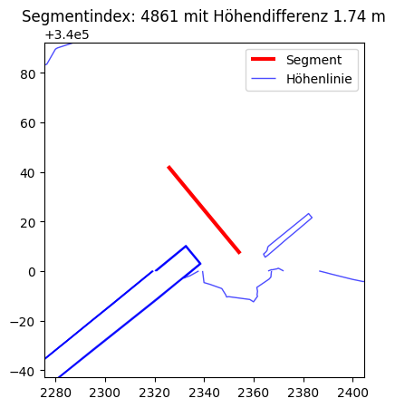

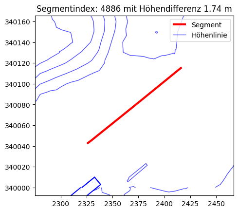

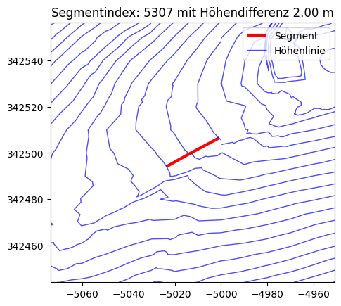

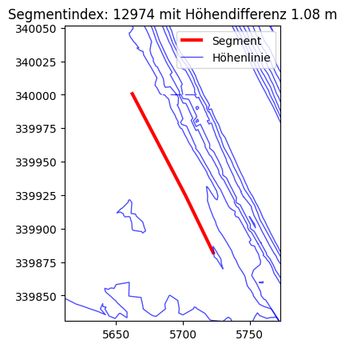

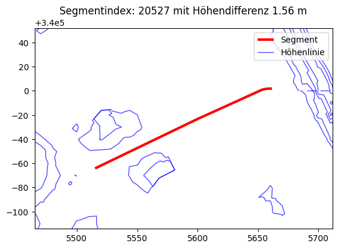

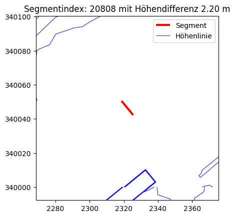

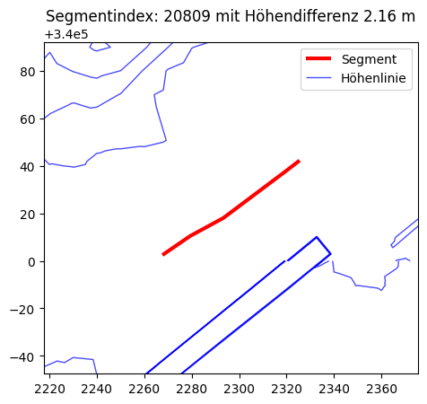

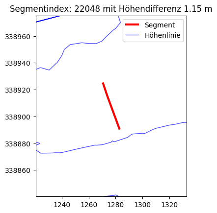

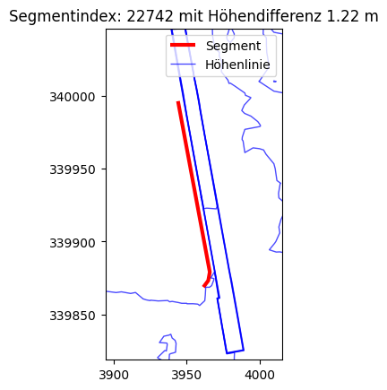

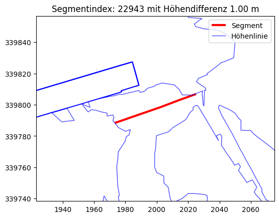

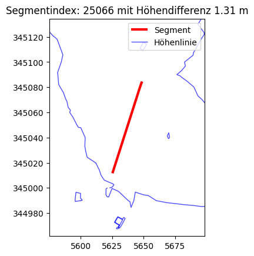

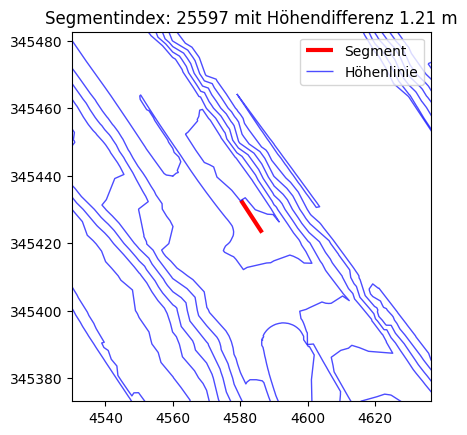

[16 more figures not shown]

```python
for idx, row in weird_segments.iterrows():
    segment = row.geometry
    buffer_dist = 50
    bbox = segment.buffer(buffer_dist).bounds
    minx, miny, maxx, maxy = bbox
    nearby_contour_lines = contour_lines.cx[minx:maxx, miny:maxy]

    fig, ax = plt.subplots()
    gpd.GeoSeries([segment]).plot(ax=ax, color='red', linewidth=3, label='Segment')
    nearby_contour_lines.plot(ax=ax, color='blue', linewidth=1, alpha=0.7, label='Höhenlinie')
    ax.set_xlim(minx, maxx)
    ax.set_ylim(miny, maxy)
    plt.legend()
    plt.title(f"Segmentindex: {idx} mit Höhendifferenz {row['elevation_delta']:.2f} m")
    plt.show()
```

Wir bilden den Steigungswerte jedes Segments auf einen Rot-Ton eines kontinuierlichen Farbschemas ab.

Besonders im Bereich des Wienerwalds gibt es viele Segmente mit Steigungswerten > 20%. Solche Steigungswerte kommen im urbanen Gebiet nicht wirklich vor, wichtiger als die korrekte farbliche Repräsentation solcher Extremwerte ist uns die leichteren Schwankungen der Steigungswerte im Stadtgebiet hervorzuheben.  
Deshalb verwenden wir das volle Spektrum des Farbschemas für Werte im Bereich von 0 - 15% an. Steigungswerte darüber erhalten den gleichen Farbwert wie 15%.

```python
normalize = mcolors.Normalize(vmin=0, vmax=0.15, clip=True)
colormap = plt.cm.get_cmap('Reds')

def slope_to_color(s):
    if pd.isna(s):
        return "#e4e4e4ff"
    rgba = colormap(normalize(s))
    return mcolors.to_hex(rgba)

segments['color'] = segments['slope'].apply(slope_to_color)
```

Vier color-stops für die Legende:

```python
for i in range(4):
    value = i * 0.2 / 4
    color = mcolors.to_hex(colormap(normalize(value)))
    print(f"Neigung {value:.2f}: {color}")
```

```
Neigung 0.00: #fff5f0
Neigung 0.05: #fca082
Neigung 0.10: #e32f27
Neigung 0.15: #67000d
```

Für die Visualisierung brauchen wir außerdem die Summe der Länge aller Segmente als magische Konstante...

```python
segments[segments['slope'] != None]['length'].sum() / 1000
```

```
np.float64(3645.1989480988705)
```

... und die Segmente als GeoJSON.

```python
segments.to_crs(epsg=4326).drop(columns=['elevation_delta']).to_file('web/segments.geojson', driver='GeoJSON', id_generate=True)
```